# A1: Preprocesamiento de los datos

Gonzalo Mellizo-Soto Díaz

29 de octubre, 2018

## Pregunta 1

1. *Cargar el archivo de datos en R y hacer una breve descripción del archivo donde se indique el número de registros, el número de variables y los nombres de las variables. Recuerda que antes de cargar el archivo, se inspeccionará de qué tipo de formato csv se trata para que la lectura sea apropiada.*

Para realizar este apartado primero debemos fijarnos en como se encuentra el csv inicialmente para observar el separador que utiliza. En este caso se observa como se utiliza un separador por comas.

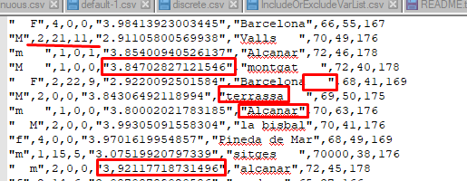

Por otro lado, tambíen se observan distintos problemas en un vistazo inicial, como separadores decimales por comas, ciudades que empiezan por mayúscula o minúscula, espacio en los extremos de las palabras…

Por ahora se va a cargar el csv con el separador para limpiar preprocesar los datos que nos encontremos.

```r
dataDf <- read.csv('Fumadores_raw.csv', stringsAsFactors = FALSE)
head(dataDf)
```

```
##      Sex Sport Years Cig               PC                  City Weight Age
## 1   M        1    25  10 2.57917010238911             Barcelona     65  49
## 2      F     1    18  32  1.5570436932541              Terrassa     65  35
## 3      M     4     0   0             <NA>             La Bisbal     69  38
## 4   M        2    25  14 2.76216877363087             Blanes        70  55
## 5      M     1     0   0 3.48707480481952 Sant Boi de Llobregat     72  55
## 6   F        4     0   0 4.07515447427575             Barcelona     64  42
##   Height
## 1    171
## 2    166
## 3    175
## 4    176
## 5    178
## 6    165
```

Se observa como al cargar el fichero ciertas variables se cargan con clases que no les corresponde, como PC que se carga como tipo character debido a las comas que se encuentran dentro de estos valores.

Se va a realizar una pequeña exploración utilizando la función `str`:

```r
str(dataDf)
```

```
## 'data.frame':    300 obs. of  9 variables:
##  $ Sex   : chr  "M   " "F" "M" "M   " ...
##  $ Sport : int  1 1 4 2 1 4 1 1 1 1 ...
##  $ Years : int  25 18 0 25 0 0 33 0 0 5 ...
##  $ Cig   : int  10 32 0 14 0 0 15 0 1 12 ...
##  $ PC    : chr  "2.57917010238911" "1.5570436932541" NA "2.76216877363087" ...
##  $ City  : chr  "Barcelona" "  Terrassa" "  La Bisbal" "Blanes   " ...
##  $ Weight: int  65 65 69 70 72 64 69 71 72000 73 ...
##  $ Age   : int  49 35 38 55 55 42 55 44 45 35 ...
##  $ Height: int  171 166 175 176 178 165 175 177 178 179 ...
```

Con este código podemos observar la estructura del objeto en R, se trata de un dataframe de 300 observaciones y 9 variables. Para ayudar a la compresión de los datos se va a realizar un “diccionario” de las variables que nos aporte el significado de cada variable:

- **Sex**: sexo de la persona entrevistada
- **Sport**: escala de la cantidad de deporte realizado, de 1 a 4.
- **Years**: años como fumador
- **Cig**: cantidad de cigarrillos
- **PC**: medida FEF
- **City**: ciudad de residencia
- **Weight**: peso de la persona entrevistada
- **Age**: edad de la persona entrevistada
- **Height**: altura de lapersona entrevistada

## Pregunta 2

2. *Indicar el tipo de variable estadística de cada variable*

Vamos a ver un pequeño ejemplo de los datos para clasificarla según su tipo de variable:

```r
head(dataDf)
```

```
##      Sex Sport Years Cig               PC                  City Weight Age
## 1   M        1    25  10 2.57917010238911             Barcelona     65  49
## 2      F     1    18  32  1.5570436932541              Terrassa     65  35
## 3      M     4     0   0             <NA>             La Bisbal     69  38
## 4   M        2    25  14 2.76216877363087             Blanes        70  55
## 5      M     1     0   0 3.48707480481952 Sant Boi de Llobregat     72  55
## 6   F        4     0   0 4.07515447427575             Barcelona     64  42
##   Height
## 1    171
## 2    166
## 3    175
## 4    176
## 5    178
## 6    165
```

```r
apply(dataDf,2, class)
```

```
##         Sex       Sport       Years         Cig          PC        City
## "character" "character" "character" "character" "character" "character"
##      Weight         Age      Height
## "character" "character" "character"
```

- **Sex**: categorica-nominal, solo debe de tomar los valores M o F
- **Sport**: categorica-ordinal, se trata de una escala ordenada, de menos a más
- **Years**: cuantitativa-discreta, dado que solo se toman años enteros y que no existen edades negativas
- **Cig**: cuantitativa-discreta, solo se toma una cantidad de cigarrillos enteros y que no existe una cantidad negativa de cigarrillos
- **PC**: cuantitativa-continua al tratarse de un cociente de litros por segundo y poder tomar valores intermedios
- **City**: categorica-nominal al tratarse de ciudades no existe una ordenación
- **Weight**: cuantitativa-continua a pesar de que se encuentre redondeada, puede tomar valores decimales
- **Age**: cuantitativa-discreta toma valores enteros
- **Height**: cuantitativa-continua se encuentra redondeada pero podría incluir valores de milímetros como decimales

**Nota:** dentro de las variables, algunas cuantitativas discretas podrían considerarse como continuas, por ejemplo un 1.5 en years podría considerarse como año y medio (365 * 1.5 días), sin embargo se van a tratar como variables cuantitativas-discretas.

## Pregunta 3

3. *En caso que R no asigne el tipo apropiado a alguna variable, realizar la conversión necesaria para que el tipo final de cada variable sea adecuado. Como por ejemplo, posibles errores de variables cuantitativas con confusión de separador decimal.*

En este apartado nos podemos encontrar con que la variable “PC” se le ha asignado una clase character cuando debe de ser numérica (las otras variables de tipo chr se mantienen así hasta realizar las transformaciones apropiadas). Por ello vamos a comenzar la transformación para adecuarlo al punto, para ello se va a sustituir todas las apariciones comas por puntos, dado que se verifica que NO existe un separador de millares, en este caso si intentaramos transformarlo directamente a numérico se introducirían NAs

**ANTES**

```r
head(dataDf$PC, 25)
```

```
##  [1] "2.57917010238911" "1.5570436932541"  NA
##  [4] "2.76216877363087" "3.48707480481952" "4.07515447427575"
##  [7] NA                 "3.39701288553318" "3.56809742342914"
## [10] "3.06803421561928" "3.74719007204417" "2.46509948086292"
## [13] "4.14217090190705" "2.61104728072071" "3.60604925973793"
## [16] "2.90113142052949" "4,07311005561473" "2.64614520341675"
## [19] "2.33307002458982" "2,54115935009075" "3.54310358421188"
## [22] "1,89718734439006" "2.26911415597005" "3.75718695215587"
## [25] "3.82309866418289"
```

**DESPUÉS**

```r
dataDf$PC <- as.numeric(gsub(pattern = ',',replacement = '.', dataDf$PC))
head(dataDf$PC, 25)
```

```
##  [1] 2.579170 1.557044       NA 2.762169 3.487075 4.075154       NA
##  [8] 3.397013 3.568097 3.068034 3.747190 2.465099 4.142171 2.611047
## [15] 3.606049 2.901131 4.073110 2.646145 2.333070 2.541159 3.543104
## [22] 1.897187 2.269114 3.757187 3.823099
```

## Pregunta 4

4. *Normalizar / Estandarizar variables cuantitativas*

Dado que hemos definido de que variables se tratan, vamos a identificarlas en un vector para realizar la limpieza (y aprovechamos y nos creamos el vector con las categóticas):

```r
numericalVariables <- c('Years', 'Cig', 'PC', 'Weight', 'Age', 'Height')
categoricalVariables <- names(dataDf)[!names(dataDf) %in% numericalVariables]
```

Estandarizamos la variable PC a tres cifras decimales (ya tiene el separador decimal a punto):

```r
dataDf$PC <- round(dataDf$PC,3)
head(dataDf$PC, 25)
```

```
##  [1] 2.579 1.557    NA 2.762 3.487 4.075    NA 3.397 3.568 3.068 3.747
## [12] 2.465 4.142 2.611 3.606 2.901 4.073 2.646 2.333 2.541 3.543 1.897
## [23] 2.269 3.757 3.823
```

En el resto de las variables no se necesita realizar un redondeo dado que se tratan de variables sin valores decimales.

## Pregunta 5

5. *Normalizar / Estandarizar variables cualitativas*

Para la variable `Sex` se va a proceder a estandarizarlo a valores de M y F, si hacemos una previsualización, se puede observar como no todas están en mayúsculas y varias contienen espacios:

```r
head(dataDf$Sex)
```

```
## [1] "M   "   "F"      "M"      "M   "   "M"      "  F   "
```

Para eliminar los espacios utilizaremos `trimws()`, mientras que para ponerlo en mayúsculas `toupper()`

```r
dataDf$Sex <- toupper(trimws(dataDf$Sex))
head(dataDf$Sex, 25)
```

```
##  [1] "M" "F" "M" "M" "M" "F" "M" "M" "M" "M" "M" "F" "M" "M" "M" "F" "F"
## [18] "M" "M" "F" "M" "M" "M" "F" "M"
```

Por otro lado para poner la primera letra como mayúscula se va a utilizar la función `toTitleCase()` incluida en el paquete base `tools`, además se eliminarán los espacios para `City` al igual que en `Sex`:

```r
dataDf$City <- toTitleCase(trimws(dataDf$City))
head(dataDf$City, 25)
```

```
##  [1] "Barcelona"             "Terrassa"
##  [3] "La Bisbal"             "Blanes"
##  [5] "Sant Boi De Llobregat" "Barcelona"
##  [7] "Terrassa"              "Terrassa"
##  [9] "Barcelona"             "Barcelona"
## [11] "Barcelona"             "Sitges"
## [13] "Solsona"               "Sitges"
## [15] "Terrassa"              "Barcelona"
## [17] "Girona"                "Tossa"
## [19] "Terrassa"              "Sitges"
## [21] "Pineda De Mar"         "Barcelona"
## [23] "Barcelona"             "Barcelona"
## [25] "Barcelona"
```

**Nota:** la palabra “De” también se incluye en mayúscula la primera letra, al no indicarse en los criterios de la actividad el NO realizarlo en preposiciones. En este caso se podría realuzar un `gsub()` que lo modifique (en otros casos se podría utilizar un diccionario de palabras para sustituirlas).

Para facilitar el mapeo de los nuevos valores en `Sport` se va a transformar a factor (ordered) para utilizar las funciones base de esta clase

```r
dataDf$Sport <- as.ordered(dataDf$Sport)
levels(dataDf$Sport)
```

```
## [1] "1" "2" "3" "4"
```

Ahora se pueden cambiar directamente los niveles por las letras equivalentes

```r
levels(dataDf$Sport) <- c('N', 'S', 'R', 'E')
levels(dataDf$Sport)
```

```
## [1] "N" "S" "R" "E"
```

```r
is.ordered(dataDf$Sport)
```

```
## [1] TRUE
```

```r
head(dataDf$Sport, 10)
```

```
##  [1] N N E S N E N N N N
## Levels: N < S < R < E
```

Una vez normalizados y estandarizados las variables se transforman en factor

```r
dataDf$Sex <- as.factor(dataDf$Sex)
levels(dataDf$Sex)
```

```
## [1] "F" "M"
```

```r
dataDf$City <- as.factor(dataDf$City)
levels(dataDf$City)
```

```
##  [1] "Alcanar"               "Barcelona"
##  [3] "Blanes"                "Cadaques"
##  [5] "Cardedeu"              "Cardona"
##  [7] "Girona"                "La Bisbal"
##  [9] "Lleida"                "Montgat"
## [11] "Pineda De Mar"         "Puigcerda"
## [13] "Ripoll"                "Sant Boi De Llobregat"
## [15] "Sitges"                "Solsona"
## [17] "Tarragona"             "Terrassa"
## [19] "Tossa"                 "Valls"
```

El dataset queda de la siguiente manera

```r
head(dataDf)
```

```
##   Sex Sport Years Cig    PC                  City Weight Age Height
## 1   M     N    25  10 2.579             Barcelona     65  49    171
## 2   F     N    18  32 1.557              Terrassa     65  35    166
## 3   M     E     0   0    NA             La Bisbal     69  38    175
## 4   M     S    25  14 2.762                Blanes     70  55    176
## 5   M     N     0   0 3.487 Sant Boi De Llobregat     72  55    178
## 6   F     E     0   0 4.075             Barcelona     64  42    165
```

```r
str(dataDf)
```

```
## 'data.frame':    300 obs. of  9 variables:
##  $ Sex   : Factor w/ 2 levels "F","M": 2 1 2 2 2 1 2 2 2 2 ...
##  $ Sport : Ord.factor w/ 4 levels "N"<"S"<"R"<"E": 1 1 4 2 1 4 1 1 1 1 ...
##  $ Years : int  25 18 0 25 0 0 33 0 0 5 ...
##  $ Cig   : int  10 32 0 14 0 0 15 0 1 12 ...
##  $ PC    : num  2.58 1.56 NA 2.76 3.49 ...
##  $ City  : Factor w/ 20 levels "Alcanar","Barcelona",..: 2 18 8 3 14 2 18 18 2 2 ...
##  $ Weight: int  65 65 69 70 72 64 69 71 72000 73 ...
##  $ Age   : int  49 35 38 55 55 42 55 44 45 35 ...
##  $ Height: int  171 166 175 176 178 165 175 177 178 179 ...
```

## Pregunta 6

6. *Revisar posibles inconsistencias entre variables: Years vs Cig.*

Para ello se van a identificar aquellas observaciones que cumplen con las inconsitstencias, fumadores sin cigarrillos o no fumadores con cigarrillos:

**Caso 1**

```r
head(dataDf[dataDf$Cig == 0 & dataDf$Years > 0 ,])
```

```
##     Sex Sport Years Cig    PC                  City Weight Age Height
## 35    M     S     5   0 3.764             Barcelona     70  46    176
## 69    F     N     5   0 3.517                 Valls     64  51    165
## 83    M     S     5   0 3.581             Barcelona     70  55    176
## 85    M     S     3   0 3.810              Terrassa     70  56    176
## 106   F     S     5   0 3.665                 Valls     67  48    168
## 107   M     N     3   0 3.646 Sant Boi De Llobregat     65  43    171
```

```r
dataDf[dataDf$Cig == 0 & dataDf$Years > 0 ,c('Cig', 'Years')] <- 0
```

```r
head(dataDf[dataDf$Cig == 0 & dataDf$Years > 0 ,])
```

```
## [1] Sex    Sport  Years  Cig    PC     City   Weight Age    Height
## <0 rows> (or 0-length row.names)
```

```r
dataDf[35,]
```

```
##    Sex Sport Years Cig    PC      City Weight Age Height
## 35   M     S     0   0 3.764 Barcelona     70  46    176
```

**Caso 2**

```r
head(dataDf[dataDf$Cig > 0 & dataDf$Years == 0 ,])
```

```
##    Sex Sport Years Cig    PC      City Weight Age Height
## 9    M     N     0   1 3.568 Barcelona  72000  45    178
## 11   M     N     0   5 3.747 Barcelona  69000  35    175
## 17   F     E     0   5 4.073    Girona     66  48    167
## 41   M     N     0   1 3.854   Alcanar     72  46    178
## 60   F     N     0   3 3.446 Barcelona     61  52    162
## 82   F     S     0   1 3.613     Valls     66  49    167
```

```r
dataDf[dataDf$Cig > 0 & dataDf$Years == 0 ,c('Cig', 'Years')] <- 0
```

```r
head(dataDf[dataDf$Cig > 0 & dataDf$Years == 0 ,])
```

```
## [1] Sex    Sport  Years  Cig    PC     City   Weight Age    Height
## <0 rows> (or 0-length row.names)
```

```r
dataDf[9,]
```

```
##   Sex Sport Years Cig    PC      City Weight Age Height
## 9   M     N     0   0 3.568 Barcelona  72000  45    178
```

## Pregunta 7

7. *Buscar valores atípicos en las variables cuantitativas*
   1. *Presentar un boxplot para cada variable cuantitativa.*
   2. *Realizar un cuadro con las estimaciones robustas y no robustas de tendencia central y dispersión para cada variable cuantitativa*

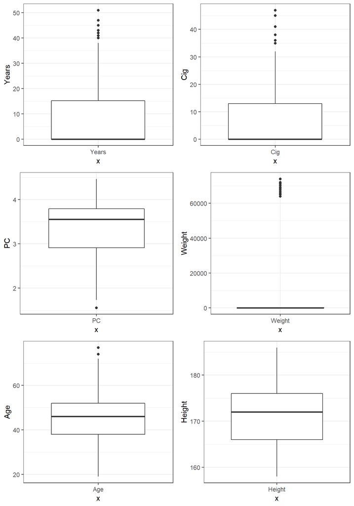

```r
  g1 <- ggplot(dataDf, aes(x = 'Years', y = Years)) +
                      geom_boxplot() +
                      theme_bw()
  g2 <- ggplot(dataDf, aes(x = 'Cig', y = Cig)) +
                      geom_boxplot() +
                      theme_bw()
  g3 <- ggplot(dataDf, aes(x = 'PC', y = PC)) +
                      geom_boxplot() +
                      theme_bw()
  g4 <- ggplot(dataDf, aes(x = 'Weight', y = Weight)) +
                      geom_boxplot() +
                      theme_bw()
  g5 <- ggplot(dataDf, aes(x = 'Age', y = Age)) +
                      geom_boxplot() +
                      theme_bw()
  g6 <- ggplot(dataDf, aes(x = 'Height', y = Height)) +
                      geom_boxplot() +
                      theme_bw()

  grid.arrange(g1, g2, g3, g4, g5, g6, nrow = 3, ncol = 2)
```

Notas sobre los resultados de los boxplots:

- Years: la mayor parte de los integrantes no fuman y los fumadores se encuentran más concentrados entre los 15 para abajo, por otro lado se encuentran outliers de personas que han fumado durante más de 35+ años, lógico cuando se piensa en la nocividad del tabaco y su repercusión en la salud.
- Cig: Al encontrarse relacionado con `Years` se observa un resultado muy similar donde lo normal es el consumo de menos de un paquete diario (20 cigarrillos) y raros casos en los que se fuma más de paquete y medio.
- PC: esta variable se encuentra bien distribuida donde la mayoría de datos se encuentran centrados en la mediana, a pesar de observarse una dispersión mayor para los valores menores. Por otro lado se encuentran outliers para personas con un PC muy bajo.
- Weight: en esta variable se encuentra una gran discordancia entre valores, esto puede deberse a las medidas realizadas en esta observación, en este caso se ha tomado el valor del peso en gramos para algunas observaciones, multiplicando el valor por 1000, por lo que habrá que solucionarlo
- Age: valores con una buena distribución centrafa sobre los ~45 años
- Height: altura centrada en los ~173 centímetros

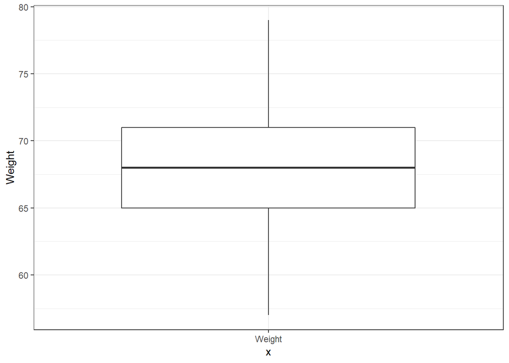

```r
dataDf$Weight[dataDf$Weight > 500] <- dataDf$Weight[dataDf$Weight > 500]/1000
ggplot(dataDf, aes(x = 'Weight', y = Weight)) +
                      geom_boxplot() +
                      theme_bw()
```

Ahora se puede observar como no se encuentran valores atípicos corregidos.

Para realizar el estudio se va a definir una función que nos devuelva los valores del estudio y se utilizará dentro de un sapply

```r
performEstimations <-  function(variable, trim){
  variable <- variable[!is.na(variable)]
  media <- mean(variable)
  media_recortada <- mean(variable, trim = trim)
  media_winsorizada <- winsor.mean(variable, trim = trim)
  mediana <- median(variable)
  desviacion_estandar <- sd(variable)
  DAM <- mad(variable)
  RIC <- IQR(variable)

  return(data.frame(media, media_recortada, media_winsorizada,
                    mediana, desviacion_estandar, DAM, RIC))
}
```

```r
cuadro <- sapply(numericalVariables, function(x){
  performEstimations(dataDf[[x]], trim = 0.05)
})
cuadro
```

```
##                     Years    Cig      PC        Weight   Age      Height
## media               8.463333 7.273333 3.331466  67.71667 45.58667 171.4367
## media_recortada     7.014815 6.111111 3.357193  67.73333 45.49259 171.4741
## media_winsorizada   8.113333 7.05     3.334263  67.71    45.54333 171.4267
## mediana             0        0        3.554     68       46       172
## desviacion_estandar 12.54165 10.41346 0.6283275 3.828653 10.62696 5.74363
## DAM                 0        0        0.541149  4.4478   10.3782  7.413
## RIC                 15.25    13       0.88075   6        14       10
```

## Pregunta 8

8. *Valores perdidos*
   1. *Buscar qué variables y registros tienen valores perdidos*
   2. *Imputar los valores a partir de los k-vecinos más cercanos usando la distancia de Gower con la información de todas las variables*

Para buscar que variables tienen NAs se utilizará la función por defecto de R, `is.na()`

```r
apply(dataDf, 2, function(x) sum(is.na(x)))
```

```
##    Sex  Sport  Years    Cig     PC   City Weight    Age Height
##      0      0      0      0      2      0      0      0      0
```

En este caso solo la variable PC contiene NAs, concretamente dos, para imputarlos se va a utilizar la función `NN()` del paquete `VIM`

```r
dataDf$PC <- kNN(dataDf)$PC
head(dataDf$PC,10)
```

```
##  [1] 2.579 1.557 3.768 2.762 3.487 4.075 2.455 3.397 3.568 3.068
```

```r
apply(dataDf, 2, function(x) sum(is.na(x)))
```

```
##    Sex  Sport  Years    Cig     PC   City Weight    Age Height
##      0      0      0      0      0      0      0      0      0
```

## Pregunta 9

9. *Hacer un breve estudio descriptivo de los datos una vez depurados*

Veamos con un pequeño estudio como quedan las cosas

```r
str(dataDf)
```

```
## 'data.frame':    300 obs. of  9 variables:
##  $ Sex   : Factor w/ 2 levels "F","M": 2 1 2 2 2 1 2 2 2 2 ...
##  $ Sport : Ord.factor w/ 4 levels "N"<"S"<"R"<"E": 1 1 4 2 1 4 1 1 1 1 ...
##  $ Years : num  25 18 0 25 0 0 33 0 0 5 ...
##  $ Cig   : num  10 32 0 14 0 0 15 0 0 12 ...
##  $ PC    : num  2.58 1.56 3.77 2.76 3.49 ...
##  $ City  : Factor w/ 20 levels "Alcanar","Barcelona",..: 2 18 8 3 14 2 18 18 2 2 ...
##  $ Weight: num  65 65 69 70 72 64 69 71 72 73 ...
##  $ Age   : int  49 35 38 55 55 42 55 44 45 35 ...
##  $ Height: int  171 166 175 176 178 165 175 177 178 179 ...
```

En este momento se observa como cada variable tiene la clase que le corresponde según si se trata de una variable cuantitativa o categórica.

```r
summary(dataDf)
```

```
##  Sex     Sport       Years             Cig               PC
##  F:137   N:127   Min.   : 0.000   Min.   : 0.000   Min.   :1.557
##  M:163   S: 83   1st Qu.: 0.000   1st Qu.: 0.000   1st Qu.:2.909
##          R: 48   Median : 0.000   Median : 0.000   Median :3.554
##          E: 42   Mean   : 8.463   Mean   : 7.273   Mean   :3.330
##                  3rd Qu.:15.250   3rd Qu.:13.000   3rd Qu.:3.793
##                  Max.   :51.000   Max.   :47.000   Max.   :4.466
##
##         City         Weight           Age            Height
##  Barcelona:102   Min.   :57.00   Min.   :19.00   Min.   :158.0
##  Terrassa : 42   1st Qu.:65.00   1st Qu.:38.00   1st Qu.:166.0
##  Valls    : 15   Median :68.00   Median :46.00   Median :172.0
##  Tarragona: 14   Mean   :67.72   Mean   :45.59   Mean   :171.4
##  Lleida   : 13   3rd Qu.:71.00   3rd Qu.:52.00   3rd Qu.:176.0
##  Sitges   : 13   Max.   :79.00   Max.   :77.00   Max.   :186.0
##  (Other)  :101
```

Se observa lo siguiente:

- El conjunto de datos tiene una mayor participación masculina
- La mayor parte no realiza ejericio o muy poco
- La mayor parte de los encuestados son no fumadores
- La ciudad con mayor participación es Barcelona
- El peso se encuentra dentro de las posibilidades de peso para hombres y mujeres
- La encuesta se ha realizado sobre personas de más de 18 años
- La altura se encuentra en valores posibles de la altura

Por otro lado en un futuro se podría estudiar la diferencia entre los fumadores y no fumadores, como por ejemplo:

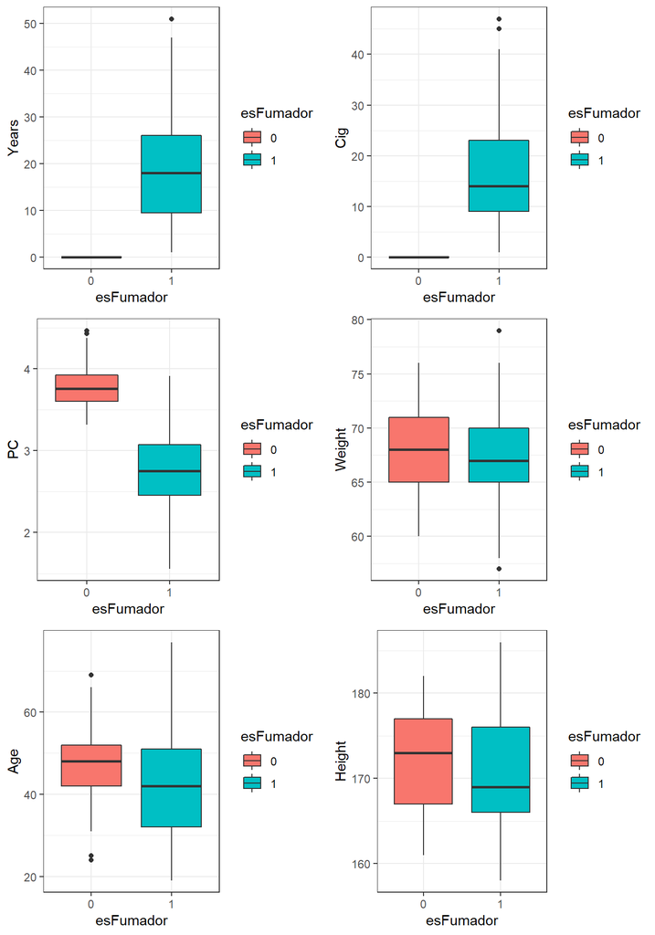

```r
  esFumador <- dataDf$Years
  esFumador[esFumador>0] <- 1
  esFumador <- as.factor(esFumador)

  g1 <- ggplot(dataDf, aes(x = esFumador, y = Years, fill = esFumador)) +
                      geom_boxplot() +
                      theme_bw()
  g2 <- ggplot(dataDf, aes(x = esFumador, y = Cig, fill = esFumador)) +
                      geom_boxplot() +
                      theme_bw()
  g3 <- ggplot(dataDf, aes(x = esFumador, y = PC, fill = esFumador)) +
                      geom_boxplot() +
                      theme_bw()
  g4 <- ggplot(dataDf, aes(x = esFumador, y = Weight, fill = esFumador)) +
                      geom_boxplot() +
                      theme_bw()
  g5 <- ggplot(dataDf, aes(x = esFumador, y = Age, fill = esFumador)) +
                      geom_boxplot() +
                      theme_bw()
  g6 <- ggplot(dataDf, aes(x = esFumador, y = Height, fill = esFumador)) +
                      geom_boxplot() +
                      theme_bw()

  grid.arrange(g1, g2, g3, g4, g5, g6, nrow = 3, ncol = 2)
```

## Pregunta 10

10. *Finalmente, crear el archivo de datos corregido*

```r
write.csv(dataDf, file = 'mellizoSoto_Fumadores_clean.csv', row.names = FALSE)
```